# Introduction to R

Jose Pablo Gomez-Vazquez

# 1. Basic operations

R is like a calculator, we can make mathematical operations, for example:

```r
2 + 2
```

```
## [1] 4
```

R is a object-oriented programming language, this means that we create objects that contain information. In R you can achieve the same results using different approaches, for example, to create an object we just type a name for the object and assign it a value using the operators `=` or `<-`. We can make operations with objects of the same type, for example:

```r
x = 2 # create a new object with the = operator
y <- 2 # create a new object with the <- operator
x + y # make a operation with the objects
```

```
## [1] 4
```

You can store more than one value using vectors, to create a vector of numbers we use `c()`. For example, we will store a sequence of numbers from 5 to 10 using 2 different approaches and then ask R if the objects are the same.  
**tip:** using the keys “alt” + “-” will automatically add the operator `<-`. Choosing which assign operator to use is a matter of preference, I personally think that is easier reading code with the operator `<-`, but a lot of people uses `=`.

```r
x <- c(5, 6, 7, 8, 9, 10) # create a sequence form 5 to 10
y = 5:10 # create the same sequence but with a different approach
x == y # ask R if the objects have the same information
```

```
## [1] TRUE TRUE TRUE TRUE TRUE TRUE
```

When we have a vector, we can ask R specific values inside an object.

```r
# Here we ask the 3rd value from our sequence
x[3]
```

```
## [1] 7
```

```r
# Now we multiply the 3rd value of the x sequence times the 5th value of the y sequence
x[3] * y[5]
```

```
## [1] 63
```

## 1.1 Functions in R

R has a lot of base functions, but we can define new functions. When using R studio, the key *Tab* will help us to auto complete, this can help us a lot when we don’t remember the exact name of the functions available. The best part of programming with R is that it has a very active community. Since its open source, anyone can create functions and compile them in a package (or library). we can download these packages and access new functions.  
Functions in R require arguments, which we can see in the function documentation or if we press the key *Tab* when we are inside the function.

```r
# To get the sum of a vector of numbers inside an object we use sum()
sum(x)
```

```
## [1] 45
```

We can put functions inside function, for example, to get $\sqrt{\sum_1^n x}$ the square root of a sum of the numbers in x we can use:

```r
sqrt(sum(x))
```

```
## [1] 6.708204
```

Making functions in R is not as complicated as it sounds and can be very useful when we need to do repetitive work. To define a function we need to include the arguments that we want for the function and what are we doing with those arguments. For example, the following function has only one argument which is a name (string) and just pastes some text before and after:

```r
F1 <- function(name){
  x <- paste("Hola", name, "! welcome to the R world!") # paste the name with some text
  print(x)
}
# trying the function (Put your name)
F1(name = "Pablo")
```

```
## [1] "Hola Pablo ! welcome to the R world!"
```

Besides storing numbers in the objects in R, we can store text, matrices, tables, spatial objects, images, and other types of objects. Next we will import our own data and do some manipulation in R.

# 2. Importing data into R

R can import data in different formats. The most common are excel files (*.csv*, *.xls* y *.xlsx*), text files *.txt* and spatial data *.shp*, which we will talk about more in detail later.  
To read *.xls*, *.xlsx* and *.shp* files we will need to install some libraries. To install a new library you need to be connected to the internet and use the function `install.packages()` to install the library. Once it has been installed, you can load the library using the function `library()`.

**Suggestion:** Sometimes when we want to use only one function from a library, we can just write the name of the library followed by the operator `::` and the name of the function, for example: `package::function()`. This way we won’t have to load the whole library.

```r
# If we dont have the library installed, we use:
# install.packages("readxl")
library(readxl) # load the library

# Import the excel file
PRRS <- readxl::read_xlsx("../Datos/PRRS.xlsx")
```

The most popular format for tables in R are called `data.frame`, when we import the data from a *.csv* o *.xlsx*. We can examine what kind of object it is using the function `class()`, an object can have more than one type of class.

```r
class(PRRS)
```

```
## [1] "tbl_df"     "tbl"        "data.frame"
```

# 3. Creating tables in R

We can use the base R functions to create basic tables. For example, we can create a table that shows the number of positive by sex:

```r
TBL <- table(PRRS$Sex, PRRS$Result)
TBL
```

```
##
##       0   1
##   H 737 229
##   M 249 138
```

When we have a table object we can ask for a specific column or row, where is represented as [row, column].

```r
TBL[,2] # Get the second column
```

```
##   H   M
## 229 138
```

## 3.1 Data manipulation with dplyr

The library `dplyr` has several functions that can help to clean, create new variables, and modify our data in other ways.

```r
# if we dont have installed the library we will need to install it using:
# install.packages("dplyr")
# we load the library:
library(dplyr)
```

`dplyr` introduces a new operator called pipes `%>%`, which can connect several functions to an object. This is an alternative to write several functions in a single “line of code” in a more organized way. For example:

**F2(F1(x)) is the same as x %>% F1() %>% F2()**

**Suggestion:** we can use the keys *Ctrl* + *shift* + *m* to insert the `%>%` operator.

We will use this to calculate the prevalence by county:

```r
PRRS %>%
  group_by(County) %>%
  summarise(N = n(), positive = sum(Result)) %>%
  mutate(Prev = positive/N) %>%
  arrange(desc(Prev))
```

```
## # A tibble: 28 × 4
##    County            N positive  Prev
##    <chr>         <int>    <dbl> <dbl>
##  1 Story            37       30 0.811
##  2 Pottawattamie    51       34 0.667
##  3 Bremer           24       14 0.583
##  4 Hardin          105       50 0.476
##  5 Scott            57       22 0.386
##  6 Audubon          19        7 0.368
##  7 Grundy           34       11 0.324
##  8 Johnson          89       27 0.303
##  9 Wright          115       33 0.287
## 10 Keokuk           18        5 0.278
## # … with 18 more rows
```

Ok, so we used several functions connected to calculate the prevalence, so I will explain it by parts:

- First we put the name of our data.
- The first function `group_by()` will group the observations by one or more variables that we indicate.
- The function `summarise()` will execute a function we define for a variable from the defined grouping variable, e.g. when we write `n()` returns the number of observations per group and with `sum(resultado)` we are summing all the positive results by each county.
- The function `mutate()` will create a new variable, we use the variables *N* and *positive* created with the previous functions and calculating the prevalence.

**Exercise:** Now try to calculate the prevalence by farm type (variable *farm_type*):

```r
# Answer
```

```r
PRRS %>%
  group_by(Sex) %>%
  summarise(media_edad = mean(Age), mediana_edad = median(Age), SD_edad = sd(Age))
```

```
## # A tibble: 2 × 4
##   Sex   media_edad mediana_edad SD_edad
##   <chr>      <dbl>        <dbl>   <dbl>
## 1 H           35.9           30    24.7
## 2 M           19.8           17    15.1
```

## 3.2 Joining datasets:

```r
# Importing the farm dataseet
nodes <- read.csv("../Datos/node_attrib.csv")
# Importing the movement dataset
mov <- read.csv("../Datos/network.csv")
# Get the number of outgoing and incoming shipments
Out <- mov %>%
  group_by(id_orig) %>%
  summarise(Outgoing = n()) %>%
  rename(id = id_orig)
In <- mov %>%
  group_by(id_dest) %>%
  summarise(Incoming = n()) %>%
  rename(id = id_dest)

# Joining the two datasets
nodes <- nodes %>%
  left_join(Out, by ="id")
nodes <- nodes %>%
  left_join(In, by = "id")
```

Now we will get the ones that had the higher number of movements:

```r
mov %>%
  group_by(id_orig) %>%
  summarise(N = n(), N_pigs = sum(pigs.moved)) %>%
  arrange(desc(N)) %>%
  head()
```

```
## # A tibble: 6 × 3
##   id_orig     N N_pigs
##     <int> <int>  <int>
## 1      29   522  50565
## 2      19   397  38686
## 3      25   154  15653
## 4      31   101  10711
## 5       8    83   7620
## 6      17    68   6633
```

# 4. Plots with R

The base plot in R includes several tools any kind of plots, some will be more straight forward than others. There are other libraries that has different functions (`ggplot2` is a very popular one), but you can achieve the same with base plots.

## Scatterplot.

This is one of the most popular kind of plots, it is useful to represent relationship between two continuous variables.  
We can achieve the same result in different ways. The first one is better when we have our variables in the same dataset, and the second one when we have data from different objects. (the length of the two vectors has to be the same).

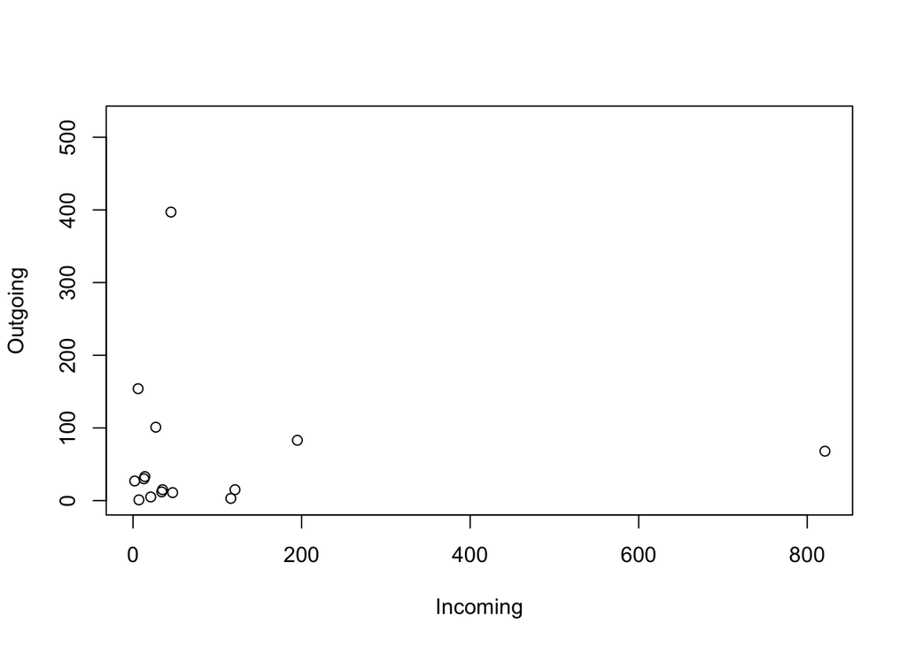

```r
# When variables are from the same dataset
plot(Outgoing~Incoming, data = nodes)
```

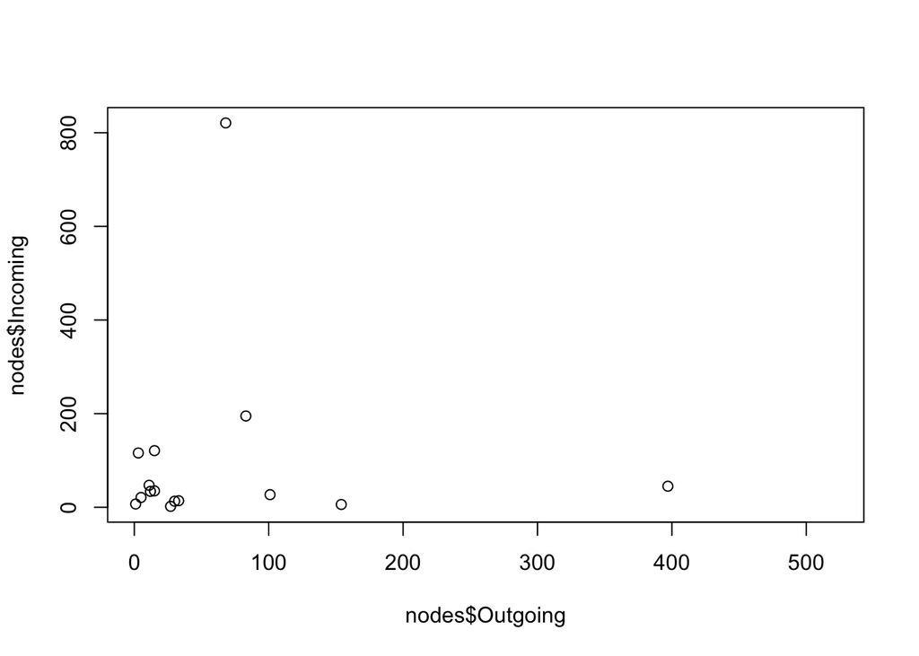

```r
# When variables from different dataset
plot(nodes$Outgoing, nodes$Incoming)
```

## Pie charts

Pie charts are useful to show proportions, for example, next we will create a plot representing the proportion of positive animals for each type of farm.  
To select a variables from a data.frame we use `$`. For example if we want to see the variable farm type from our PRRS dataset, we use `PRRS$farm_type`.

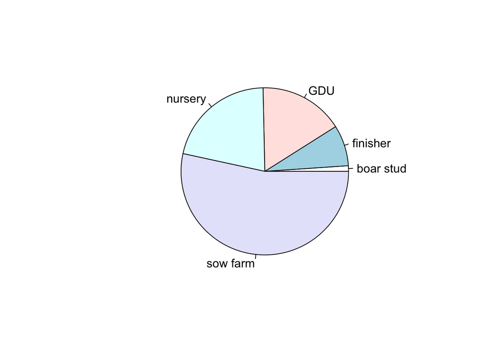

```r
# First we create a table for the result by farm type
TM <- table(PRRS$farm_type, PRRS$Result)
# Then we use the second column which contains the positive onyl
pie(TM[,2])
```

## Boxplots

Boxplots are great to show the distribution of a continuous variable. We can use it to show only one variable, or multiple variables.

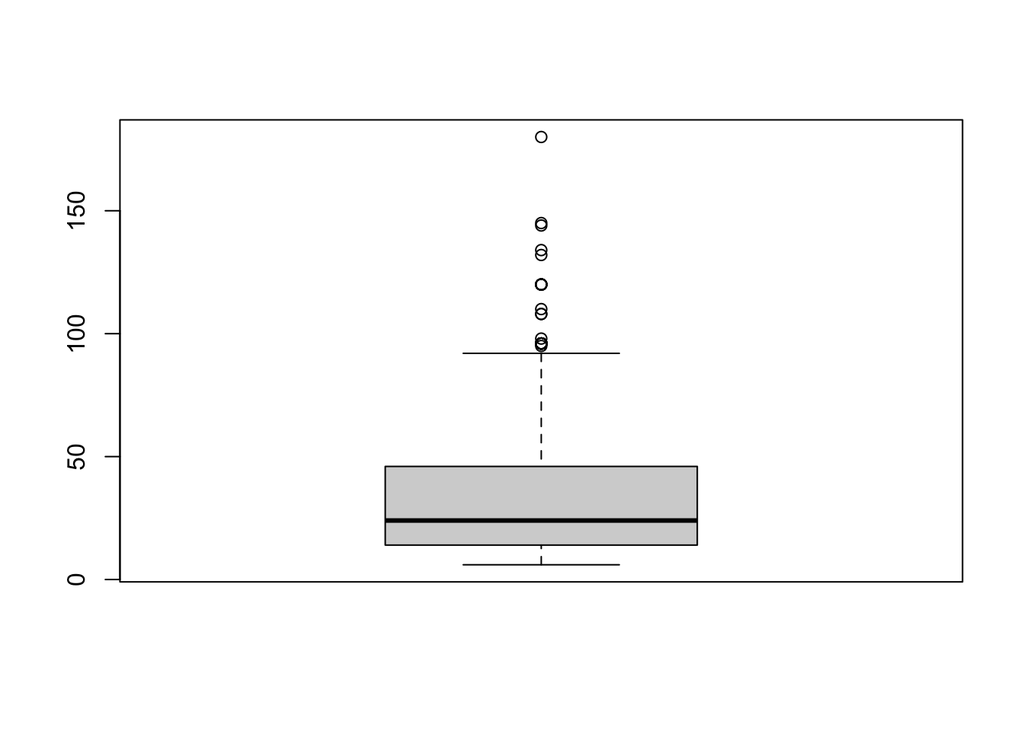

```r
# Only one variable
boxplot(x = PRRS$Age)
```

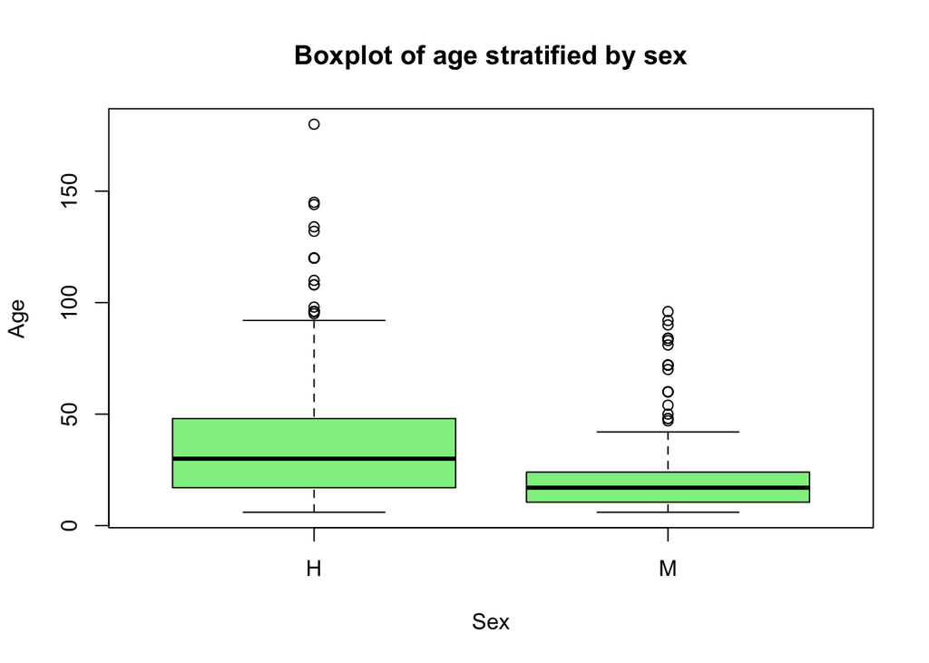

```r
# Same variable, but stratified by another
boxplot(Age~Sex, data = PRRS, col = "lightgreen",
        main = "Boxplot of age stratified by sex")
```

The plot function has a lot of arguments to customize your plots, you dont need to use them all, but the more you use, the more you can create more informative and visually appealing plots.

## Bar plot

For the next plot we will use more arguments, we will stratify the result by the sex of the animal.  
We will also use the package `RColorBrewer` to get some nice looking color palettes

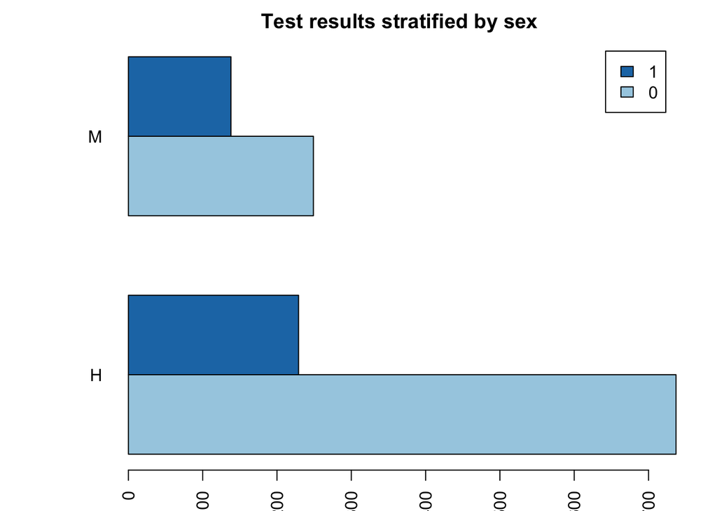

```r
# Install the package if its not already installed.
# install.packages("RColorBrewer")
# Get 4 colors from the palette.
colpal <- RColorBrewer::brewer.pal(n = 4, # Number of colors we want
                         name = "Paired") # Name of the palette
# First we will get a table with the results stratified by sex
TM <- table(PRRS$Result, PRRS$Sex)
# The we use the par() function to increase the margins:
par(mar = c(2, 6, 2, 2))
# We use the barplot function to plot the results
barplot(TM[, order(colSums(TM), decreasing = T)], # Order the results in decreasing
        beside = T, # Plot bars beside each other
        horiz = T, # change to horizontally
        las = 2, #set the names of x axis vertically
        main = "Test results stratified by sex", # Main title
        col = colpal[1:2], # we want only the first two colors of our palette
        legend = rownames(TM)) # include the row names as legend
```

**Exercise:** Create a bar plot of the results stratified by the farm type:

```r
# Answer
```

## Time series plots.

To create a time series we will need to reformat the data a little bit so R can do what we want.

```r
# First we will format the date:
mov$date <- as.Date(mov$date, "%m/%d/%y")
# The we create a variable formatting the date as week of the year:
mov$week <- format(mov$date, "%V")
```

This is basically a scatterplot joined by a line, so we use the function `plot()` with the argument `type = "l"` to join our points inn the scatterplot with a line.

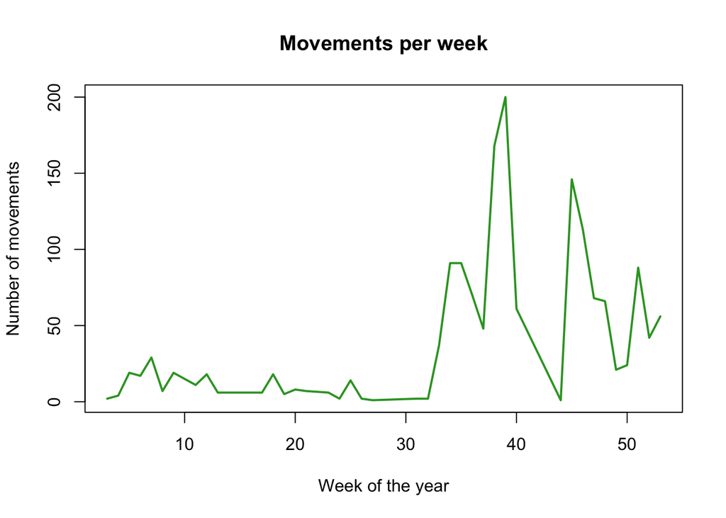

```r
# Create a table with the number of movements by week
mw <- mov %>%
  group_by(week) %>%
  summarise(N = n())
# Plot the data
plot(N~week, # Our variables
     data = mw, # our dataset
     type = "l", # we want lines
     col = colpal[4], # color 4 from the palette
     lwd = 2, # width of the line
     main = "Movements per week", # Main title
     xlab = "Week of the year", # label for x axis
     ylab = "Number of movements") # label for y axis
```

Go Back